# HW1

### Homework 1

Jan Dziuba

### Dataset

I chose the MagicTelescope dataset.  
Dataset is used for classification of high energy gamma particles in a ground-based atmospheric Cherenkov gamma telescope using the imaging technique.  
For more detailed description check  
https://www.openml.org/search?type=data&sort=runs&id=1120&status=active

Dataset contains 10 features and 19020 samples.  
Classes are imbalanced with 1.8438995215311005 ratio.

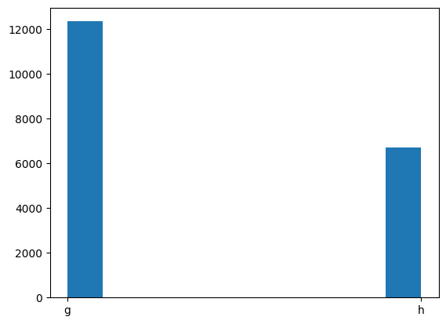

The features are not normally distributed, so they will require normalization.

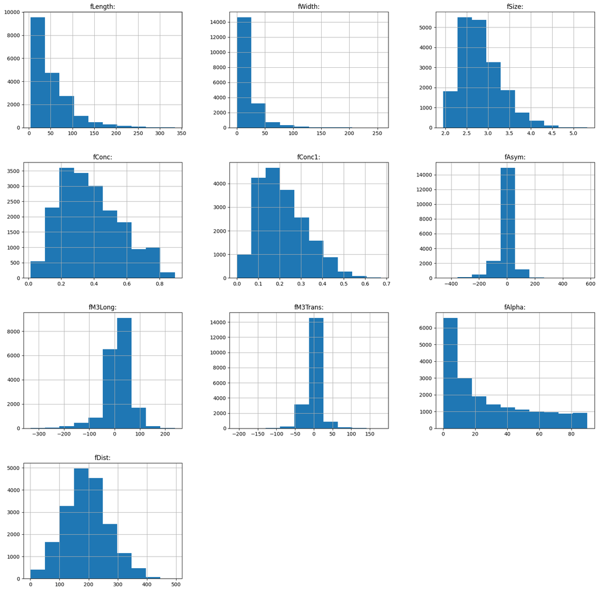

The fConc and fConc1 features are heavily correlated.  
We could consider removing one of them.

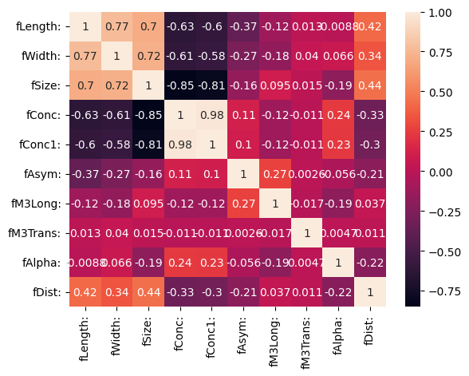

### Evaluation

I use random 20% of the data for evaluation.  
I compare 4 models.  
LogisticRegression, RandomForest, xgboost and tabpfn.  
For RandomForest and xgboost I use RandomizedSearch and cross validation to find the best hyperparameters.

For evaluation the best metric will be f1 score since it works better than AUC on imbalanced datasets.

#### Results

LogisticRegression

Accuracy: 0.7931125131440588  
Precision: 0.761012183692596  
Recall: 0.6041666666666666  
AUC: 0.8425616410181959  
F1: 0.6735794276233927

RandomForest

Accuracy: 0.8759200841219769  
Precision: 0.8682432432432432  
Recall: 0.7648809523809523  
AUC: 0.932424143437863  
F1: 0.8132911392405063

xgboost

Accuracy: 0.8832807570977917  
Precision: 0.8839590443686007  
Recall: 0.7708333333333334  
AUC: 0.9352872144792874  
F1: 0.8235294117647058

tabpfn

Accuracy: 0.867770767613039  
Precision: 0.8609442060085837  
Recall: 0.7462797619047619  
AUC: 0.9244220020325203  
F1: 0.7995217218015145

The tabpfn model is heavily disadvantaged since it only trains on 1024 samples.  
xgboost performed best across all metrics.

### Appendix

```python
import numpy as np
import pandas as pd

import matplotlib.pyplot as plt
import seaborn as sns

from sklearn.model_selection import train_test_split
from sklearn.preprocessing import StandardScaler

from sklearn.linear_model import LogisticRegression
from sklearn.ensemble import RandomForestClassifier

from sklearn.model_selection import RandomizedSearchCV

from sklearn.metrics import accuracy_score, precision_score, recall_score, roc_auc_score, f1_score

import xgboost as xgb

from tabpfn import TabPFNClassifier
```

```python
dataset = pd.read_csv('https://raw.githubusercontent.com/adrianstando/imbalanced-benchmarking-set/main/datasets/MagicTelescope.csv', index_col=0)
```

```python
dataset
```

|  | fLength: | fWidth: | fSize: | fConc: | fConc1: | fAsym: | fM3Long: | fM3Trans: | fAlpha: | fDist: | TARGET |
| --- | --- | --- | --- | --- | --- | --- | --- | --- | --- | --- | --- |
| 0 | 28.7967 | 16.0021 | 2.6449 | 0.3918 | 0.1982 | 27.7004 | 22.0110 | -8.2027 | 40.0920 | 81.8828 | g |
| 1 | 31.6036 | 11.7235 | 2.5185 | 0.5303 | 0.3773 | 26.2722 | 23.8238 | -9.9574 | 6.3609 | 205.2610 | g |
| 2 | 162.0520 | 136.0310 | 4.0612 | 0.0374 | 0.0187 | 116.7410 | -64.8580 | -45.2160 | 76.9600 | 256.7880 | g |
| 3 | 23.8172 | 9.5728 | 2.3385 | 0.6147 | 0.3922 | 27.2107 | -6.4633 | -7.1513 | 10.4490 | 116.7370 | g |
| 4 | 75.1362 | 30.9205 | 3.1611 | 0.3168 | 0.1832 | -5.5277 | 28.5525 | 21.8393 | 4.6480 | 356.4620 | g |
| ... | ... | ... | ... | ... | ... | ... | ... | ... | ... | ... | ... |
| 19015 | 21.3846 | 10.9170 | 2.6161 | 0.5857 | 0.3934 | 15.2618 | 11.5245 | 2.8766 | 2.4229 | 106.8258 | h |
| 19016 | 28.9452 | 6.7020 | 2.2672 | 0.5351 | 0.2784 | 37.0816 | 13.1853 | -2.9632 | 86.7975 | 247.4560 | h |
| 19017 | 75.4455 | 47.5305 | 3.4483 | 0.1417 | 0.0549 | -9.3561 | 41.0562 | -9.4662 | 30.2987 | 256.5166 | h |
| 19018 | 120.5135 | 76.9018 | 3.9939 | 0.0944 | 0.0683 | 5.8043 | -93.5224 | -63.8389 | 84.6874 | 408.3166 | h |
| 19019 | 187.1814 | 53.0014 | 3.2093 | 0.2876 | 0.1539 | -167.3125 | -168.4558 | 31.4755 | 52.7310 | 272.3174 | h |

19020 rows × 11 columns

```python
dataset.info()
```

```
<class 'pandas.core.frame.DataFrame'>
Int64Index: 19020 entries, 0 to 19019
Data columns (total 11 columns):
 #   Column     Non-Null Count  Dtype
---  ------     --------------  -----
 0   fLength:   19020 non-null  float64
 1   fWidth:    19020 non-null  float64
 2   fSize:     19020 non-null  float64
 3   fConc:     19020 non-null  float64
 4   fConc1:    19020 non-null  float64
 5   fAsym:     19020 non-null  float64
 6   fM3Long:   19020 non-null  float64
 7   fM3Trans:  19020 non-null  float64
 8   fAlpha:    19020 non-null  float64
 9   fDist:     19020 non-null  float64
 10  TARGET     19020 non-null  object
dtypes: float64(10), object(1)
memory usage: 1.7+ MB
```

```python
dataset.describe()
```

|  | fLength: | fWidth: | fSize: | fConc: | fConc1: | fAsym: | fM3Long: | fM3Trans: | fAlpha: | fDist: |
| --- | --- | --- | --- | --- | --- | --- | --- | --- | --- | --- |
| count | 19020.000000 | 19020.000000 | 19020.000000 | 19020.000000 | 19020.000000 | 19020.000000 | 19020.000000 | 19020.000000 | 19020.000000 | 19020.000000 |
| mean | 53.250154 | 22.180966 | 2.825017 | 0.380327 | 0.214657 | -4.331745 | 10.545545 | 0.249726 | 27.645707 | 193.818026 |
| std | 42.364855 | 18.346056 | 0.472599 | 0.182813 | 0.110511 | 59.206062 | 51.000118 | 20.827439 | 26.103621 | 74.731787 |
| min | 4.283500 | 0.000000 | 1.941300 | 0.013100 | 0.000300 | -457.916100 | -331.780000 | -205.894700 | 0.000000 | 1.282600 |
| 25% | 24.336000 | 11.863800 | 2.477100 | 0.235800 | 0.128475 | -20.586550 | -12.842775 | -10.849375 | 5.547925 | 142.492250 |
| 50% | 37.147700 | 17.139900 | 2.739600 | 0.354150 | 0.196500 | 4.013050 | 15.314100 | 0.666200 | 17.679500 | 191.851450 |
| 75% | 70.122175 | 24.739475 | 3.101600 | 0.503700 | 0.285225 | 24.063700 | 35.837800 | 10.946425 | 45.883550 | 240.563825 |
| max | 334.177000 | 256.382000 | 5.323300 | 0.893000 | 0.675200 | 575.240700 | 238.321000 | 179.851000 | 90.000000 | 495.561000 |

```python
dataset_values = dataset.values
X, y = dataset_values[:, :-1], dataset_values[:, -1]
```

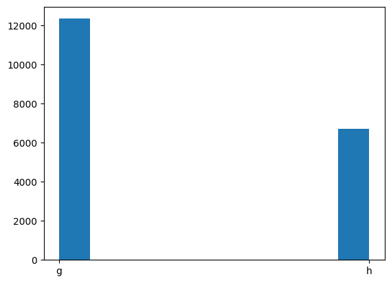

```python
# y hist
plt.hist(y)
plt.show()
```

```python
g_value_count = np.unique(y, return_counts=True)[1][0]
h_value_count = np.unique(y, return_counts=True)[1][1]
```

```python
y_ratio = g_value_count / h_value_count
y_ratio
```

```
1.8438995215311005
```

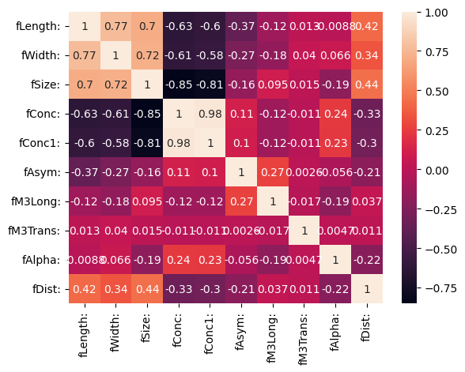

```python
sns.heatmap(dataset.corr(), annot=True)
plt.show()
```

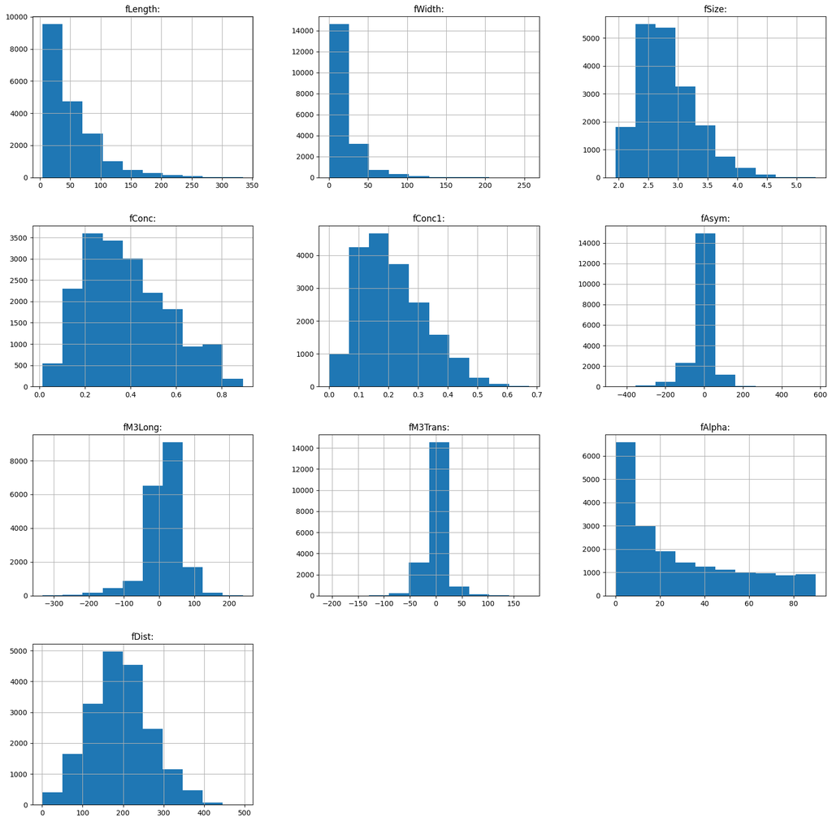

```python
dataset.hist(figsize=(20,20))
plt.show()
```

```python
# map y values to 0 and 1
y = np.where(y == 'g', 0, 1)
```

```python
# normalize X values
scaler = StandardScaler()
X = scaler.fit_transform(X)
```

```python
X_train, X_test, Y_train, Y_test = train_test_split(X, y, test_size=0.2, random_state=42)
```

```python
def evaluate_model(model, X_test, Y_test):
    pred = model.predict(X_test)
    pred_proba = model.predict_proba(X_test)[:, 1]

    accuracy = accuracy_score(Y_test, pred)
    precision = precision_score(Y_test, pred)
    recall = recall_score(Y_test, pred)
    auc = roc_auc_score(Y_test, pred_proba)
    f1 = f1_score(Y_test, pred)

    print('Accuracy: {}'.format(accuracy))
    print('Precision: {}'.format(precision))
    print('Recall: {}'.format(recall))
    print('AUC: {}'.format(auc))
    print('F1: {}'.format(f1))
```

```python
# Logistic Regression
# use f1 score as scoring metric
logreg = LogisticRegression(random_state=42)
logreg.fit(X_train, Y_train)
```

```
LogisticRegression(random_state=42)
```

```python
# Random Forest
rf = RandomForestClassifier()

# use random search to find best hyperparameters
n_estimators = [int(x) for x in np.linspace(start=50, stop=500, num=10)]
max_depth = [int(x) for x in np.linspace(10, 50, num=5)]
max_depth.append(None)
min_samples_split = [2, 5, 10, 15]
min_samples_leaf = [1, 2, 4, 8]
bootstrap = [True, False]

random_grid = {
    'n_estimators': n_estimators,
    'max_depth': max_depth,
    'min_samples_split': min_samples_split,
    'min_samples_leaf': min_samples_leaf,
    'bootstrap': bootstrap
}

rf_random = RandomizedSearchCV(estimator=rf, param_distributions=random_grid, n_iter=50, cv=3, scoring='f1', verbose=2, random_state=42, n_jobs=-1)
```

```python
rf_random.fit(X_train, Y_train)
```

[output not shown]

[output cut: 96 more lines]

[output not shown]

```
RandomizedSearchCV(cv=3, estimator=RandomForestClassifier(), n_iter=50,
                   n_jobs=-1,
                   param_distributions={'bootstrap': [True, False],
                                        'max_depth': [10, 20, 30, 40, 50, None],
                                        'min_samples_leaf': [1, 2, 4, 8],
                                        'min_samples_split': [2, 5, 10, 15],
                                        'n_estimators': [50, 100, 150, 200, 250,
                                                         300, 350, 400, 450,
                                                         500]},
                   random_state=42, scoring='f1', verbose=2)
```

```python
rf_random.best_score_
```

```
0.8158017757356336
```

```python
rf_random.best_params_
```

```
{'n_estimators': 450,
 'min_samples_split': 15,
 'min_samples_leaf': 1,
 'max_depth': 40,
 'bootstrap': True}
```

```python
# xgboost

xgb_clf = xgb.XGBClassifier()

# use random search to find best hyperparameters
n_estimators = [int(x) for x in np.linspace(start=50, stop=500, num=10)]
max_depth = [int(x) for x in np.linspace(10, 50, num=5)]
max_depth.append(None)
min_child_weight = [int(x) for x in np.linspace(1, 10, num=10)]
gamma = [int(x) for x in np.linspace(0, 10, num=10)]
gamma.append(None)
subsample = [x for x in np.linspace(0.5, 1, num=5)]
colsample_bytree = [x for x in np.linspace(0.5, 1, num=5)]
learning_rate = [x for x in np.linspace(0.01, 0.5, num=5)]

random_grid = {
    'n_estimators': n_estimators,
    'max_depth': max_depth,
    'min_child_weight': min_child_weight,
    'gamma': gamma,
    'subsample': subsample,
    'colsample_bytree': colsample_bytree,
    'learning_rate': learning_rate
}

xgb_random = RandomizedSearchCV(estimator=xgb_clf, param_distributions=random_grid, n_iter=50, cv=3, scoring='f1', verbose=2, random_state=42, n_jobs=-1)
```

```python
xgb_random.fit(X_train, Y_train)
```

[output not shown]

[output cut: 96 more lines]

[output not shown]

```
RandomizedSearchCV(cv=3,
                   estimator=XGBClassifier(base_score=None, booster=None,
                                           callbacks=None,
                                           colsample_bylevel=None,
                                           colsample_bynode=None,
                                           colsample_bytree=None,
                                           early_stopping_rounds=None,
                                           enable_categorical=False,
                                           eval_metric=None, feature_types=None,
                                           gamma=None, gpu_id=None,
                                           grow_policy=None,
                                           importance_type=None,
                                           interaction_constraints=None,
                                           learning_rate...
                   param_distributions={'colsample_bytree': [0.5, 0.625, 0.75,
                                                             0.875, 1.0],
                                        'gamma': [0, 1, 2, 3, 4, 5, 6, 7, 8, 10,
                                                  None],
                                        'learning_rate': [0.01, 0.1325, 0.255,
                                                          0.3775, 0.5],
                                        'max_depth': [10, 20, 30, 40, 50, None],
                                        'min_child_weight': [1, 2, 3, 4, 5, 6,
                                                             7, 8, 9, 10],
                                        'n_estimators': [50, 100, 150, 200, 250,
                                                         300, 350, 400, 450,
                                                         500],
                                        'subsample': [0.5, 0.625, 0.75, 0.875,
                                                      1.0]},
                   random_state=42, scoring='f1', verbose=2)
```

```python
xgb_random.best_score_
```

```
0.819772372183528
```

```python
xgb_random.best_params_
```

```
{'subsample': 0.875,
 'n_estimators': 300,
 'min_child_weight': 4,
 'max_depth': 30,
 'learning_rate': 0.1325,
 'gamma': 6,
 'colsample_bytree': 0.625}
```

```python
# TabPFN
tab_fpn = TabPFNClassifier(N_ensemble_configurations=32)

X_train_1024 = X_train[:1024]
Y_train_1024 = Y_train[:1024]

tab_fpn.fit(X_train_1024, Y_train_1024)
```

```
Loading model that can be used for inference only
Using a Transformer with 25.82 M parameters
```

```
TabPFNClassifier(N_ensemble_configurations=32)
```

```python
# evaluate logistic regression
evaluate_model(logreg, X_test, Y_test)
```

```
Accuracy: 0.7931125131440588
Precision: 0.761012183692596
Recall: 0.6041666666666666
AUC: 0.8425616410181959
F1: 0.6735794276233927
```

```python
# evaluate random forest
evaluate_model(rf_random, X_test, Y_test)
```

```
Accuracy: 0.8759200841219769
Precision: 0.8682432432432432
Recall: 0.7648809523809523
AUC: 0.932424143437863
F1: 0.8132911392405063
```

```python
# eval xgboost model
evaluate_model(xgb_random, X_test, Y_test)
```

```
Accuracy: 0.8832807570977917
Precision: 0.8839590443686007
Recall: 0.7708333333333334
AUC: 0.9352872144792874
F1: 0.8235294117647058
```

```python
# eval TabPFN model
evaluate_model(tab_fpn, X_test, Y_test)
```

```
Accuracy: 0.867770767613039
Precision: 0.8609442060085837
Recall: 0.7462797619047619
AUC: 0.9244220020325203
F1: 0.7995217218015145
```